# Simulated tumours: multi-sample data

Giulio Caravagna and Timon Heide

12/03/2020

```r
require(dplyr)
require(ggplot2)
require(mobster)
```

This page describes the multi-sample synthetic data used to test MOBSTER, and shows how to run the analysis on multi-region datasets.

**Note.** Each of the simulated datasets has been generated using a spatial simulator that we are about the release and link through this page.

# Available cohort

The simulations have been collected in the simulation_2d.rds RDS object..

```r
simulation_2d = readRDS("./simulation_2d.rds")

# Number of simulations
print(length(simulation_2d))
```

```
#> [1] 15
```

We release data from `n = 15` simulated tumours with different number of subclones and biopsies; the overall set of simulations used in the paper (`n > 500`) is too large to attach (`>10GB`).

Simulations have unique ids; for instance is the same tumour (`seed = 1`) with `k = 2` clones (`1` subclone), where we simulated different spatial sampling strategies, genrating from `n = 2` to `n = 6` biopsies.

```r
# [1] ".//multivar_2_clones_var_samples/simulation_set-1_seed-1_n-2.rds"
# [2] ".//multivar_2_clones_var_samples/simulation_set-1_seed-1_n-3.rds"
# [3] ".//multivar_2_clones_var_samples/simulation_set-1_seed-1_n-4.rds"
# [4] ".//multivar_2_clones_var_samples/simulation_set-1_seed-1_n-5.rds"
# [5] ".//multivar_2_clones_var_samples/simulation_set-1_seed-1_n-6.rds"
#
print(names(simulation_2d))
```

```
#>  [1] ".//multivar_2_clones_var_samples/simulation_set-1_seed-1_n-2.rds"
#>  [2] ".//multivar_2_clones_var_samples/simulation_set-1_seed-1_n-3.rds"
#>  [3] ".//multivar_2_clones_var_samples/simulation_set-1_seed-1_n-4.rds"
#>  [4] ".//multivar_2_clones_var_samples/simulation_set-1_seed-1_n-5.rds"
#>  [5] ".//multivar_2_clones_var_samples/simulation_set-1_seed-1_n-6.rds"
#>  [6] ".//multivar_3_clones_var_samples/simulation_set-1_seed-20_n-2.rds"
#>  [7] ".//multivar_3_clones_var_samples/simulation_set-1_seed-20_n-3.rds"
#>  [8] ".//multivar_3_clones_var_samples/simulation_set-1_seed-20_n-4.rds"
#>  [9] ".//multivar_3_clones_var_samples/simulation_set-1_seed-20_n-5.rds"
#> [10] ".//multivar_3_clones_var_samples/simulation_set-1_seed-20_n-6.rds"
#> [11] ".//multivar_neutral_var_samples/simulation_set-1_seed-2_n-2.rds"
#> [12] ".//multivar_neutral_var_samples/simulation_set-1_seed-2_n-3.rds"
#> [13] ".//multivar_neutral_var_samples/simulation_set-1_seed-2_n-4.rds"
#> [14] ".//multivar_neutral_var_samples/simulation_set-1_seed-2_n-5.rds"
#> [15] ".//multivar_neutral_var_samples/simulation_set-1_seed-2_n-6.rds"
```

# Analysis of a neutral tumour

We show how to fit one of the simulated cases; we begin loading the data.

```r
# Use one case (neutral with 2 biopsies)
id = names(simulation_2d)[11]
print(id)
```

```
#> [1] ".//multivar_neutral_var_samples/simulation_set-1_seed-2_n-2.rds"
```

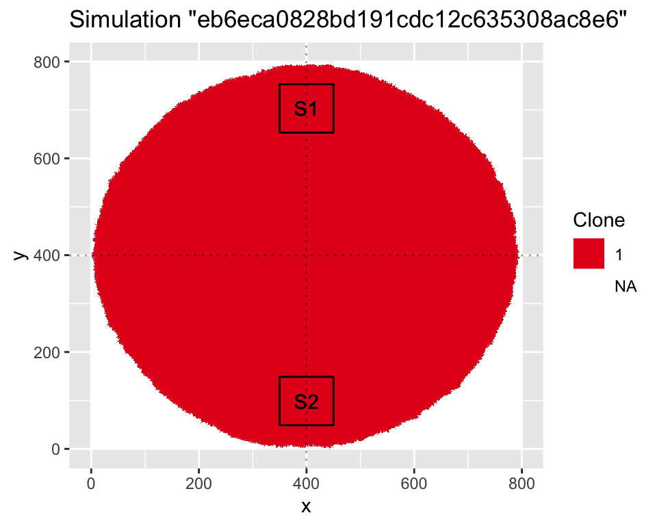

```r
# Plot the tumour
simulation_2d[[id]]$plot %>% print
```

```r
# Get tumour data (sequencing)
tumour = simulation_2d[[id]]$sequencing
print(tumour)
```

```
#> # A tibble: 4,944 x 4
#>    id      variable value sample
#>    <chr>   <chr>    <dbl> <chr>
#>  1 __mut1  VAF      0.472 S1
#>  2 __mut2  VAF      0.549 S1
#>  3 __mut3  VAF      0.455 S1
#>  4 __mut4  VAF      0.472 S1
#>  5 __mut5  VAF      0.531 S1
#>  6 __mut6  VAF      0.573 S1
#>  7 __mut7  VAF      0.549 S1
#>  8 __mut8  VAF      0.495 S1
#>  9 __mut9  VAF      0.420 S1
#> 10 __mut10 VAF      0.443 S1
#> # … with 4,934 more rows
```

```r
# Samples
samples = tumour$sample %>% unique
print(samples)
```

```
#> [1] "S1" "S2"
```

## MOBSTER tail detection

We run MOBSTER on each VAF value above 5%, with fast setup (`auto_setup = 'FAST'`) for the tool to speed up the vignette.

```r
fits = lapply(samples,
       function(s)
       {
         tumour  %>%
           filter(sample == s) %>%
           spread(variable, value) %>%
           filter(VAF > 0.05) %>%
           mobster_fit(auto_setup = 'FAST')
       })
```

```
#>  [ MOBSTER fit ]
#>
#>
#>
#>
#>
#>  [ MOBSTER fit ]
```

```r
names(fits) = samples
```

We can visualise the fits with an in-line plot of MOBSTER fits.

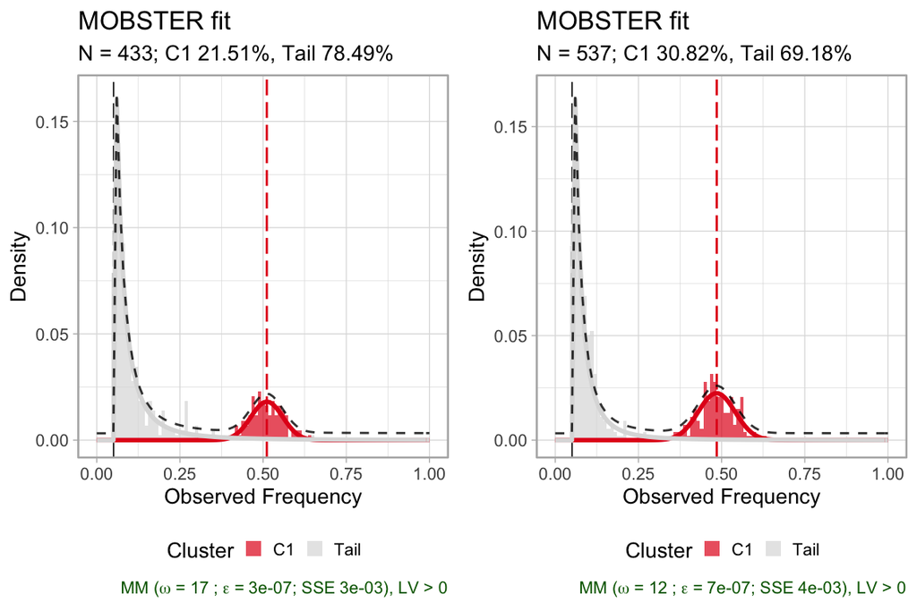

```r
ggpubr::ggarrange(plotlist = lapply(fits, function(x) plot(x$best)), nrow = 1) %>% print
```

We can then compute a table with all the available clustering assignments (to find tail mutations).

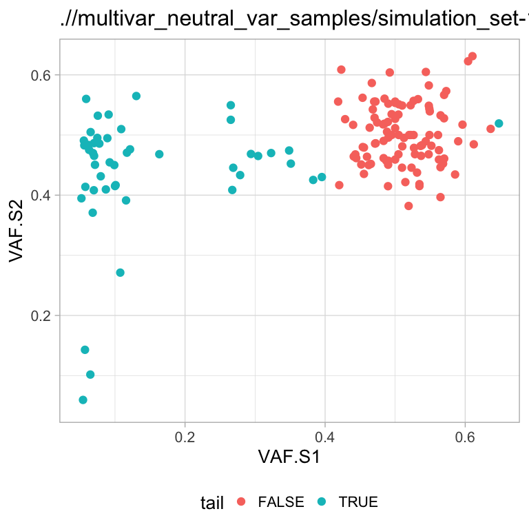

```r
# Join clustering assignments
myjoin = function(x, y) {
  full_join(x, y, by = 'id')
}

assignments = lapply(names(fits), function(x){
 D = fits[[x]]$best$data
 colnames(D)[2:ncol(D)] = paste0(colnames(D)[2:ncol(D)], '.', x)
 D
})
assignments = Reduce(myjoin, assignments)

# Find tail mutations
assignments$tail = assignments %>%
  select(starts_with('cluster')) %>%
  apply(
    MARGIN = 1,
    FUN = function(w) {
      any(w == 'Tail', na.rm = TRUE)
    }
  )

ggplot(assignments, aes(x = VAF.S1, y = VAF.S2, color = tail)) +
  geom_point() +
  mobster:::my_ggplot_theme() +
  labs(title = id)
```

We then compute which mutations are ever clustered into a `Tail`, and remove those. We extract read counts data for non-tail mutations which we can use for Binomial mixture modelling.

```r
# Non-tail mutations
non_tail = assignments %>%
  filter(!tail) %>%
  pull(id)

# Read counts
reads_data = lapply(samples, function(s) {
  tumour  %>%
    filter(sample == s) %>%
    spread(variable, value)
})
reads_data = Reduce(myjoin, reads_data)

print(reads_data)
```

```
#> # A tibble: 824 x 9
#>    id       sample.x  DP.x  NV.x  VAF.x sample.y  DP.y  NV.y VAF.y
#>    <chr>    <chr>    <dbl> <dbl>  <dbl> <chr>    <dbl> <dbl> <dbl>
#>  1 __mut1   S1         108    51 0.472  S2         109    53 0.486
#>  2 __mut10  S1          88    39 0.443  S2         124    58 0.468
#>  3 __mut100 S1         108    61 0.565  S2         107    57 0.533
#>  4 __mut101 S1          91     5 0.0549 S2          92     0 0
#>  5 __mut102 S1         106     7 0.0660 S2          79     0 0
#>  6 __mut103 S1         123     9 0.0732 S2         104     0 0
#>  7 __mut104 S1          95     7 0.0737 S2          91     0 0
#>  8 __mut105 S1         107     8 0.0748 S2          84     0 0
#>  9 __mut106 S1         108    13 0.120  S2         100     0 0
#> 10 __mut107 S1         109    10 0.0917 S2         102     0 0
#> # … with 814 more rows
```

## Read-counts analysis after MOBSTER

Multi-region read-counts clustering with multivariate Binomial distributions is implemented in [VIBER](https://caravagn.github.io/VIBER/index.html).

```r
require(VIBER)

# Disable parallel run (for VIBER)
options(easypar.parallel = FALSE)
```

This is the actual analysis, removing tails via `filter(id %in% non_tail)`.

```r
# Depth and number reads with the variant as two lists
dp = reads_data %>% filter(id %in% non_tail) %>% select(starts_with('DP'))
nv = reads_data %>% filter(id %in% non_tail) %>% select(starts_with('NV'))

colnames(dp) = colnames(nv) = samples

# Fit and plot
multivariate_binomial_MOBSTER = VIBER::variational_fit(
  nv,
  dp,
  K = 5,
  description = id)
```

```
#>  [ VIBER - variational fit ]
```

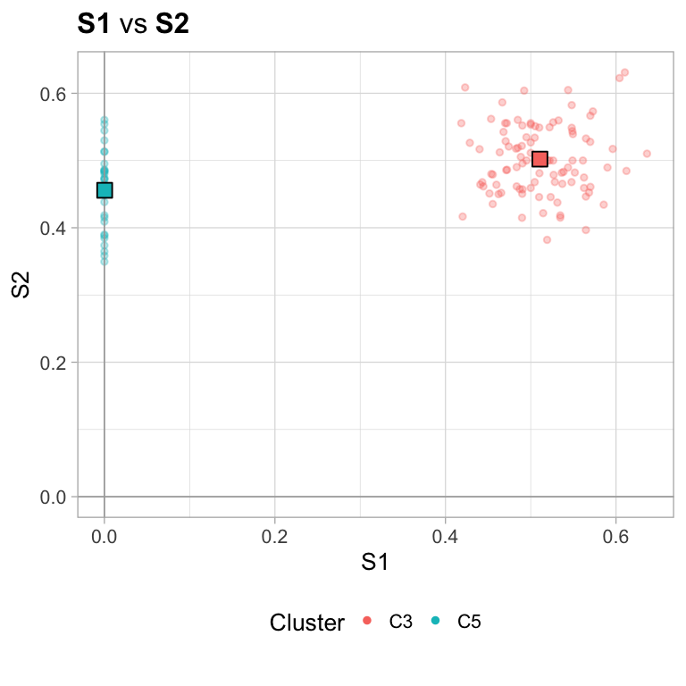

```r
ggpubr::ggarrange(plotlist = plot(multivariate_binomial_MOBSTER), nrow = 1)
```

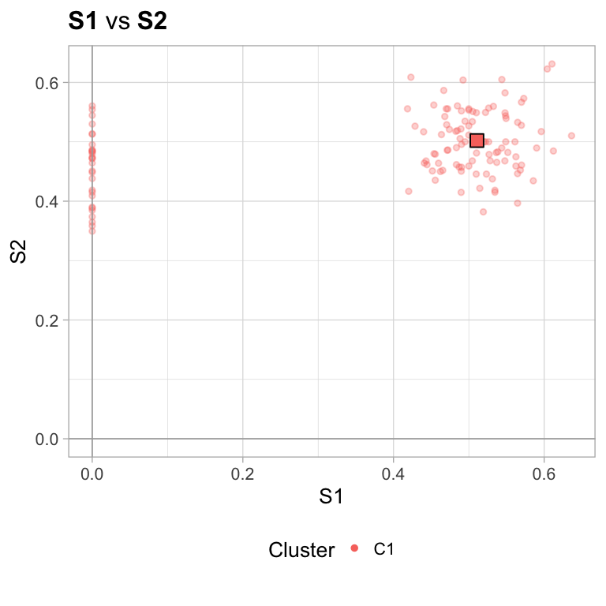

```r
# Reduce clusters with the proposed heuristic and replot
ggpubr::ggarrange(
  plotlist = plot(
    choose_clusters(multivariate_binomial_MOBSTER, dimensions_cutoff = 1)
    ),
  nrow = 1)
```

## Standard read-counts analysis without MOBSTER

We here use all the read data

```r
# Depth and number reads with the variant as two lists
dp = reads_data %>% select(starts_with('DP'))
nv = reads_data %>% select(starts_with('NV'))

colnames(dp) = colnames(nv) = samples

# Fit and plot
multivariate_binomial = VIBER::variational_fit(nv, dp, K = 5, description = id)
```

```
#>  [ VIBER - variational fit ]
```

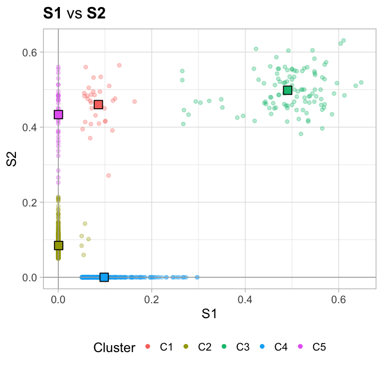

```r
ggpubr::ggarrange(plotlist = plot(multivariate_binomial), nrow = 1)
```

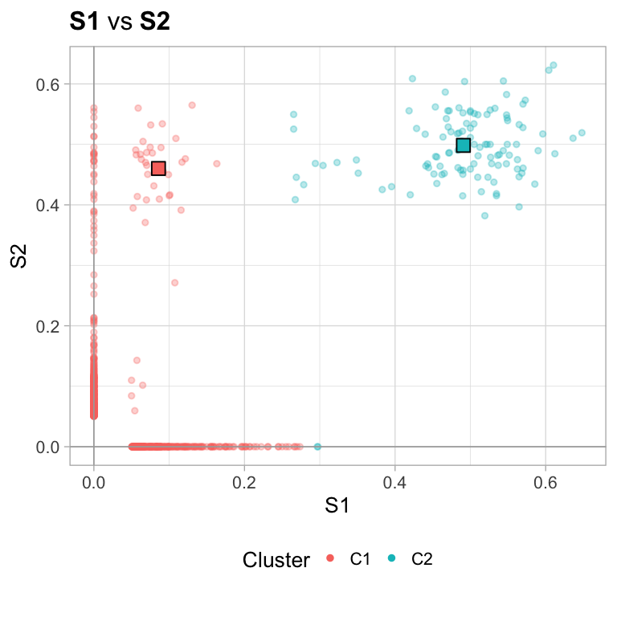

```r
# Reduce cluasters with the proposed heuristic and replot
ggpubr::ggarrange(
  plotlist = plot(
    choose_clusters(multivariate_binomial, dimensions_cutoff = 1)
    ),
  nrow = 1)
```

# Analysis of a tumour with one subclone

We show a subclone with two boundary biopsies (that contains cells from both the ancestral and the subclonal population that is expanding).

```r
id = names(simulation_2d)[1]
print(id)
```

```
#> [1] ".//multivar_2_clones_var_samples/simulation_set-1_seed-1_n-2.rds"
```

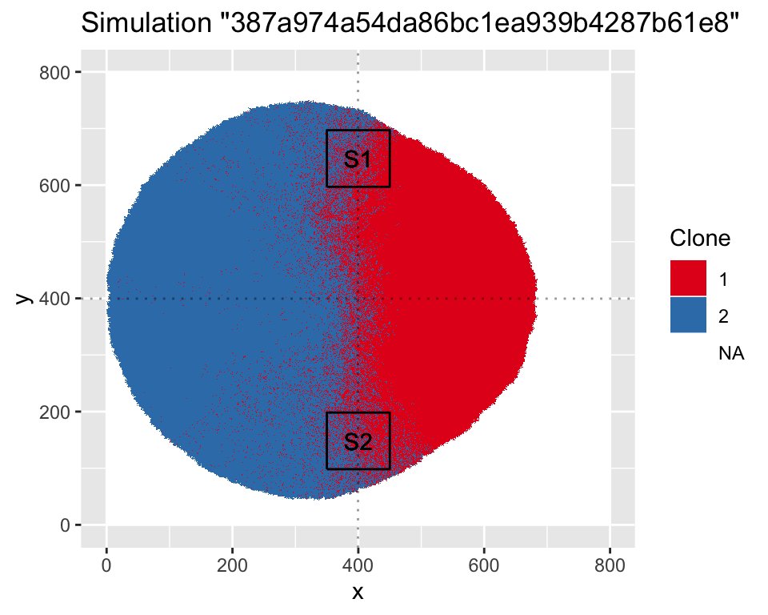

```r
# Plot the tumour
simulation_2d[[id]]$plot %>% print
```

```r
# Get tumour data (sequencing)
tumour = simulation_2d[[id]]$sequencing
samples = tumour$sample %>% unique
print(samples)
```

```
#> [1] "S1" "S2"
```

## MOBSTER tail detection

```r
# Run MOBSTER on each VAF value above 5%, with fast setup
fits = lapply(samples,
       function(s)
       {
         tumour  %>%
           filter(sample == s) %>%
           spread(variable, value) %>%
           filter(VAF > 0.05) %>%
           mobster_fit(auto_setup = 'FAST')
       })
```

```
#>  [ MOBSTER fit ]
#>
#>
#>
#>
#>
#>  [ MOBSTER fit ]
```

```r
names(fits) = samples
```

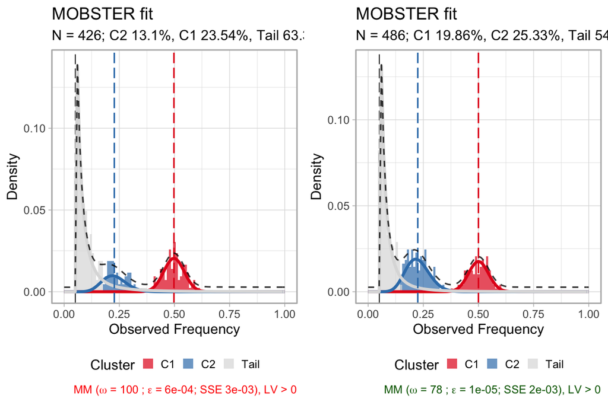

```r
# MOBSTER inline plots
ggpubr::ggarrange(plotlist = lapply(fits, function(x) plot(x$best)), nrow = 1) %>% print
```

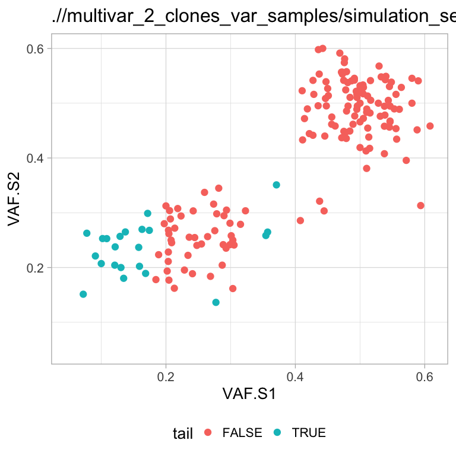

```r
assignments = lapply(names(fits), function(x){
 D = fits[[x]]$best$data
 colnames(D)[2:ncol(D)] = paste0(colnames(D)[2:ncol(D)], '.', x)
 D
})
assignments = Reduce(myjoin, assignments)

# Find tail mutations
assignments$tail = assignments %>%
  select(starts_with('cluster')) %>%
  apply(
    MARGIN = 1,
    FUN = function(w) {
      any(w == 'Tail', na.rm = TRUE)
    }
  )

ggplot(assignments, aes(x = VAF.S1, y = VAF.S2, color = tail)) +
  geom_point() +
  mobster:::my_ggplot_theme() +
  labs(title = id)
```

## Read-counts analysis after MOBSTER

```r
# Non-tail mutations
non_tail = assignments %>%
  filter(!tail) %>%
  pull(id)

# Read counts
reads_data = lapply(samples, function(s) {
  tumour  %>%
    filter(sample == s) %>%
    spread(variable, value)
})
reads_data = Reduce(myjoin, reads_data)
```

```r
# Depth and number reads with the variant as two lists
dp = reads_data %>% filter(id %in% non_tail) %>% select(starts_with('DP'))
nv = reads_data %>% filter(id %in% non_tail) %>% select(starts_with('NV'))

colnames(dp) = colnames(nv) = samples

# Fit and plot
multivariate_binomial_MOBSTER = VIBER::variational_fit(
  nv,
  dp,
  K = 5,
  description = id)
```

```
#>  [ VIBER - variational fit ]
```

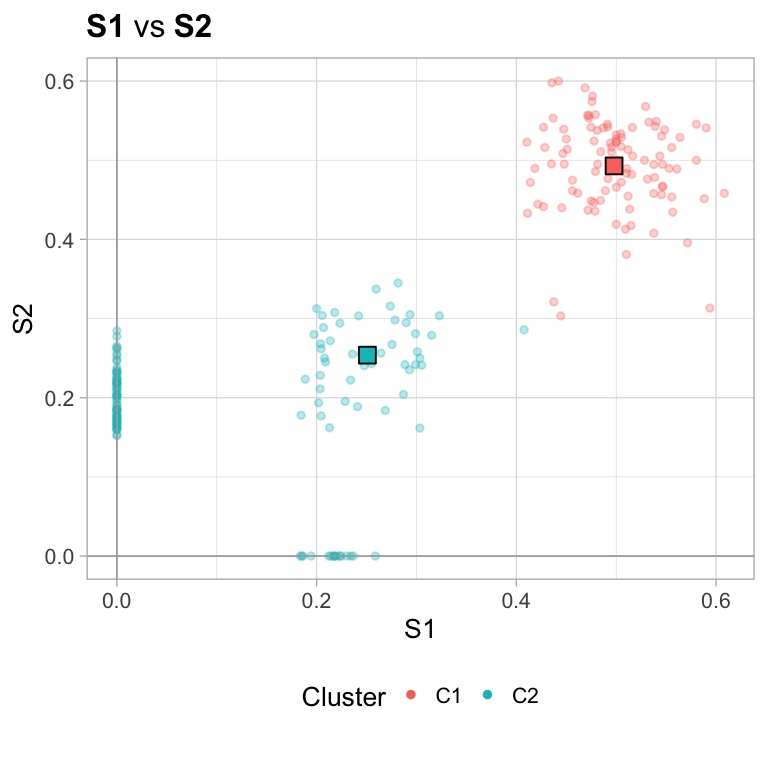

```r
# Reduce cluasters with the proposed heuristic and replot
ggpubr::ggarrange(
  plotlist = plot(
    choose_clusters(multivariate_binomial_MOBSTER, dimensions_cutoff = 1)
    ),
  nrow = 1)
```

## Standard read-counts analysis without MOBSTER

```r
# Depth and number reads with the variant as two lists
dp = reads_data %>% select(starts_with('DP'))
nv = reads_data %>% select(starts_with('NV'))

colnames(dp) = colnames(nv) = samples

# Fit and plot
multivariate_binomial = VIBER::variational_fit(nv, dp, K = 5, description = id)
```

```
#>  [ VIBER - variational fit ]
```

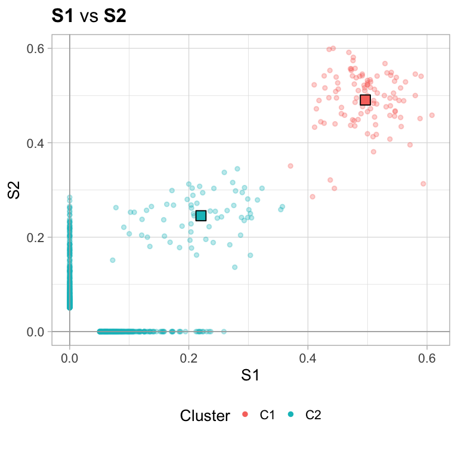

```r
# Reduce cluasters with the proposed heuristic and replot
ggpubr::ggarrange(
  plotlist = plot(
    choose_clusters(multivariate_binomial, dimensions_cutoff = 1)
    ),
  nrow = 1)
```